# Text Mining Comparisons of General v Curated Datasets

Lauren Onweller and Daniel Reker

The goal of this code is to read in abstracts from csv files, downloaded from large literature databases, and analyze them through various methods.

```r
rm(list = ls()) # start with clear environment
```

To start, we must load in all required packages for the code

```r
# Load all required packages
library(tidyverse)
library(quanteda)         # For NLP
library(quanteda.textmodels)
library(quanteda.textplots)
library(quanteda.textstats)
library(readtext)         # To read .txt files
library(PubMedWordcloud)  # pull abstracts from PMID


library(stm)              # For structural topic models
library(stminsights)      # For visual exploration of STM
library(wordcloud)        # To generate wordclouds
library(wordcloud2)        # To generate wordclouds
library(gsl)              # Required for the topicmodels package
library(topicmodels)      # For topicmodels
library(caret)            # For machine learning
library(ggplot2)          # For plotting
library(ggrepel)          # For adding labels to scatterplots
library(tm)
library(cowplot) # multiple plots
library(qdapTools)  #text mining associations
```

Now we can use the PubMedWordcloud package to retrieve PMIDs and pull abstracts from the csv fie Documentation for PubMedWordcloud: https://cran.r-project.org/web/packages/PubMedWordcloud/PubMedWordcloud.pdf

General Search abstracts We now move on to make a corpus with the abstracts, tokenize everything, and make a document frequency matrix

```r
# Choose the file of abstracts.
Combo_NP_CSV <- read.csv(file = file.choose())

abstract_Gen <- Combo_NP_CSV$Abstract
#abstract_Gen <- read.csv(file = file.choose()) [ ,c('Abstract')]

# Create a doc by using corpus
mycorpus_Gen <- corpus(abstract_Gen)

mycorpus_Gen.stats <- summary(mycorpus_Gen)

# And print the statistics of the first 10 observations
# head(mycorpus_Gen.stats, n = 10)


# Create tokens
token_Gen <-
  tokens(
    mycorpus_Gen,
    remove_numbers = TRUE,
    remove_punct = TRUE,
    remove_symbols = TRUE,
    remove_url = TRUE,
    split_hyphens = TRUE,
    include_docvars = TRUE
  )
token_a_Gen <-tokens_remove(token_Gen, pattern = c('doi*', 'author*', 'pmid*','pmcid*','usa*', 'medlin*', 'pub*', 'arti*', 'depart*', 'univers*'), padding = FALSE)
# print(head(token_a_Gen))
# Clean tokens created by OCR
token_clean_Gen <- tokens_select(
  token_a_Gen,
  c("[\\d-]", "[[:punct:]]", "^.{1,2}$"),
  selection = "remove",
  valuetype = "regex",
  verbose = TRUE
)
```

```
removed 23,940 features
```

Stem and further clean tokens and make into a dfm

```r
mydfm_Gen <- token_clean_Gen
mydfm_Gen <- tokens_remove(mydfm_Gen, stopwords("english"))
mydfm_Gen <- dfm(mydfm_Gen)
mydfm_Gen <-  dfm_wordstem(mydfm_Gen, language = quanteda_options("language_stemmer"))
```

Now we can read in the Database papers

We now move on to make a corpus with the abstracts, tokenize everything, and make a document frequency matrix

```r
# Choose the file of abstracts. only do this step if you do not have abstracts loaded
research_NP_CSV <- read.csv(file = file.choose())
abstract_research <- research_NP_CSV$Abstract

# Create a doc by using corpus
mycorpus_research <- corpus(abstract_research)
# Save statistics in "mycorpus.stats"
mycorpus_research.stats <- summary(mycorpus_research)

# And print the statistics of the first 10 observations
# head(mycorpus_research.stats, n = 10)

# Create tokens
token_research <-
  tokens(
    mycorpus_research,
    remove_numbers = TRUE,
    remove_punct = TRUE,
    remove_symbols = TRUE,
    remove_url = TRUE,
    split_hyphens = TRUE,
    include_docvars = TRUE
  )
token_a_research <-tokens_remove(token_research, pattern = c('doi*', 'author*', 'pmid*','pmcid*','usa*', 'medlin*', 'pub*', 'arti*', 'depart*', 'univers*'), padding = FALSE)

# Clean tokens created by OCR
token_clean_research <- tokens_select(
  token_a_research,
  c("[\\d-]", "[[:punct:]]", "^.{1,2}$"),
  selection = "remove",
  valuetype = "regex",
  verbose = TRUE
)
```

```
removed 993 features
```

Stem and further clean tokens and make into a dfm

```r
mydfm_research <- token_clean_research
mydfm_research <- tokens_remove(mydfm_research,stopwords("english"))
mydfm_research <- dfm(mydfm_research)
mydfm_research <- dfm_wordstem(mydfm_research,language = quanteda_options("language_stemmer"))
```

Plot general and research Word clouds next to eachother

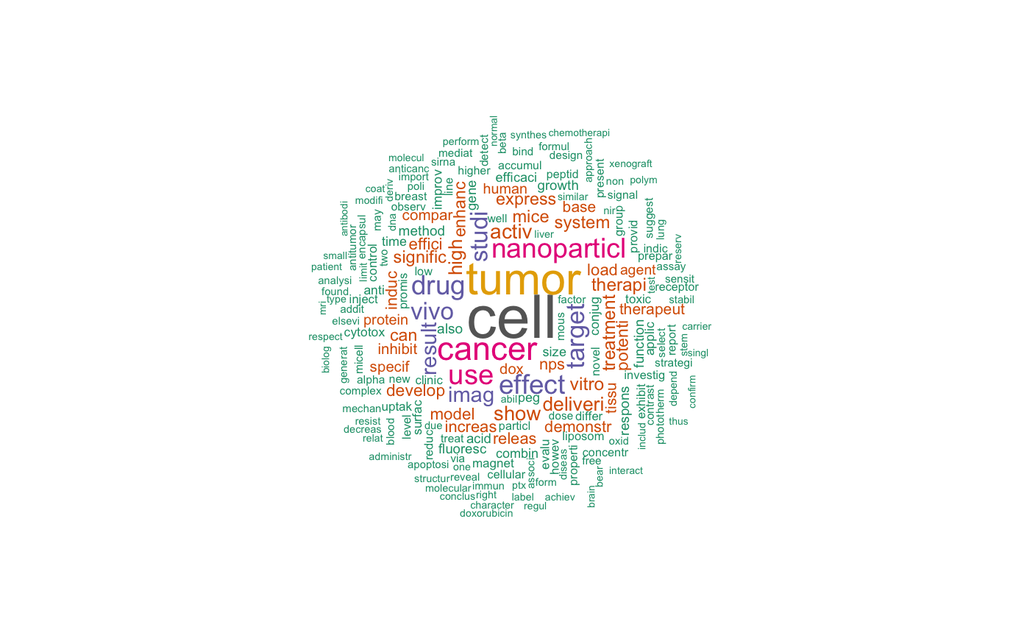

```r
# Wordcloud Gen
set.seed(1234)
dev.new(width = 2000, height = 2000, unit = "px")  #plots in new window
textplot_wordcloud(mydfm_Gen, rotation= 0.35,
                   max_words=200,
                   color=brewer.pal(8, "Dark2"))
```

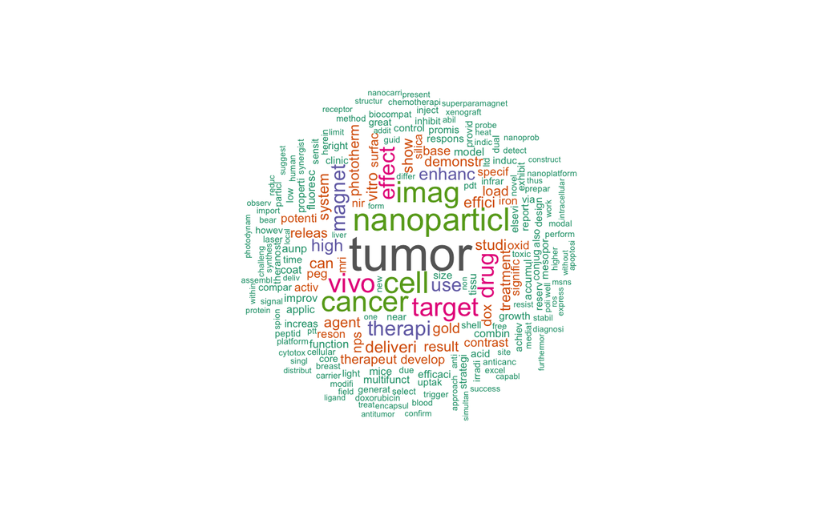

```r
# Wordcloud research
set.seed(1234)
dev.new(width = 2000, height = 2000, unit = "px")  #plots in new window
textplot_wordcloud(mydfm_research, rotation= 0.35,
                   max_words=200,
                   color=brewer.pal(8, "Dark2"))
```

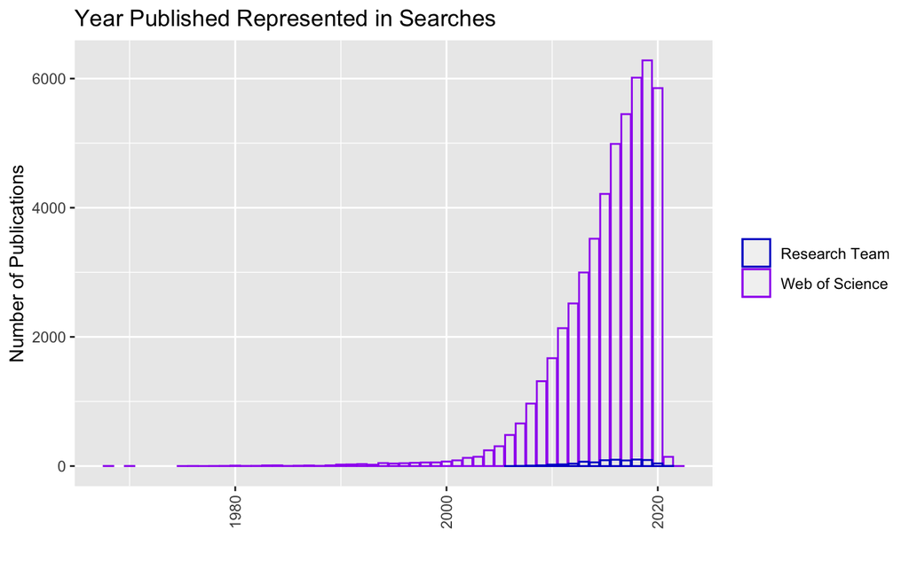

```r
# read in csv files with information of article, journal, year publication, etc
Gen_NP_CSV <- Combo_NP_CSV

# geom_bar is designed to make it easy to create bar charts that show
# counts (or sums of weights)
year <- research_NP_CSV$Publication.Year

legend_colors <- c("Web of Science"="purple", "Research Team"="mediumblue")

ggplot(NULL, aes(x)) +
  geom_bar(data=Gen_NP_CSV, aes(x=Publication.Year, color="Web of Science"), fill = NA, stat = "count") +  # general
  geom_bar(data=research_NP_CSV, aes(x=Publication.Year, color="Research Team"), fill = NA, stat = "count") +  # research
  theme(legend.position = "right", legend.title=element_blank(), axis.text.x = element_text(angle=90, vjust=.5, hjust=1)) +
  ggtitle("Year Published Represented in Searches") +
  ylab("Number of Publications") +
  xlab("") +
  scale_color_manual(values = legend_colors)
```

Plot proportion not count

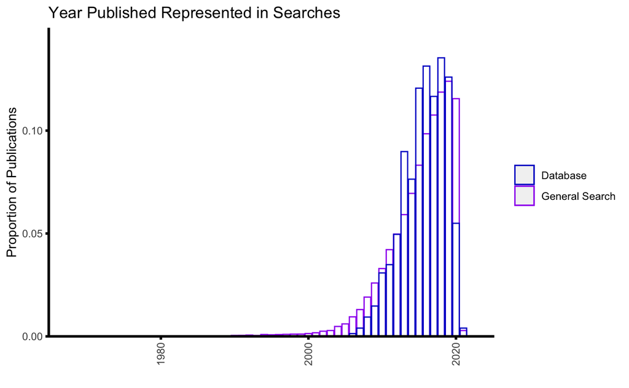

```r
legend_colors <- c("General Search"="purple", "Database"="mediumblue")
ggplot(NULL, aes(x = Publication.Year)) +
  geom_bar(data = Gen_NP_CSV, aes(y = (..count..)/sum(..count..), color="General Search"), fill = NA) +  # general
  geom_bar(data=research_NP_CSV, aes(y = (..count..)/sum(..count..), color="Database"), fill = NA) +  # research
  scale_y_continuous()+
 theme(legend.position = "right", legend.title=element_blank(), axis.text.x = element_text(angle=90, vjust=.5, hjust=1), ,  panel.grid.major = element_blank(),
  panel.grid.minor = element_blank(),
  panel.border = element_blank(),
  panel.background = element_blank(),
  plot.background = element_blank(),
  axis.line = element_line(colour="black", size = 1),
  axis.ticks = element_line(colour="black", size = 1)) +
  ggtitle("Year Published Represented in Searches") +
  ylab("Proportion of Publications") +
  xlab("") +
  scale_color_manual(values = legend_colors) +
  scale_y_continuous(limits = c(0, 0.15), expand = expansion(mult = c(0, 0)))
```

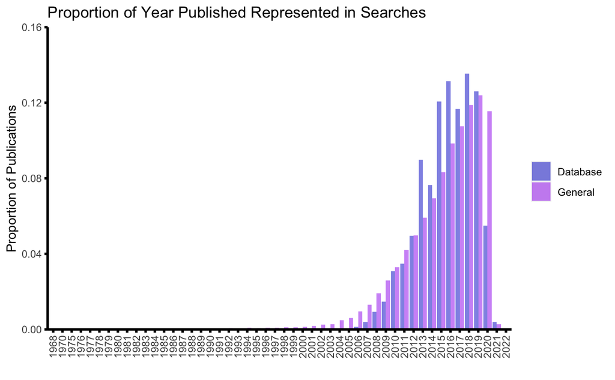

```r
data_general = data.frame(table(Gen_NP_CSV$Publication.Year))
colnames(data_general)[1] <- "Year"
colnames(data_general)[2] <- "Count_Gen"
data_general['Proportion_Gen'] <- data_general$Count_Gen/sum(data_general$Count_Gen)


data_db = data.frame(table(research_NP_CSV$Publication.Year))
colnames(data_db)[1] <- "Year"
colnames(data_db)[2] <- "Count_Database"
data_db['Proportion_Database'] <- data_db$Count_Database/sum(data_db$Count_Database)

data_frame_d <- merge(data_general, data_db, all = TRUE)
data_frame_d[is.na(data_frame_d)] <- 0

data_frame_new_d = data.frame(source= c(rep("General", length(data_frame_d$Year)), rep("Database", length(data_frame_d$Year))),
                  year = c(rep(data_frame_d$Year,2)),
                  proportion= c(data_frame_d$Proportion_Gen, data_frame_d$Proportion_Database) )



ggplot(data=data_frame_new_d) +
 geom_bar(aes(x=year, y = proportion, fill=source),
          position="dodge", stat="identity", alpha=0.5) +
  scale_fill_manual(values = c("mediumblue", "purple"))+
  theme(legend.position = "right", legend.title=element_blank(), axis.text.x = element_text(angle=90, vjust=.5, hjust=1),panel.grid.major = element_blank(),
  panel.grid.minor = element_blank(),
  panel.border = element_blank(),
  panel.background = element_blank(),
  plot.background = element_blank(),
  axis.line = element_line(colour="black", size = 1),
  axis.ticks = element_line(colour="black", size = 1)) +
  ggtitle("Proportion of Year Published Represented in Searches") +
  ylab("Proportion of Publications") +
  xlab("") +
  scale_y_continuous(limits = c(0, 0.16), expand = expansion(mult = c(0, 0)))
```

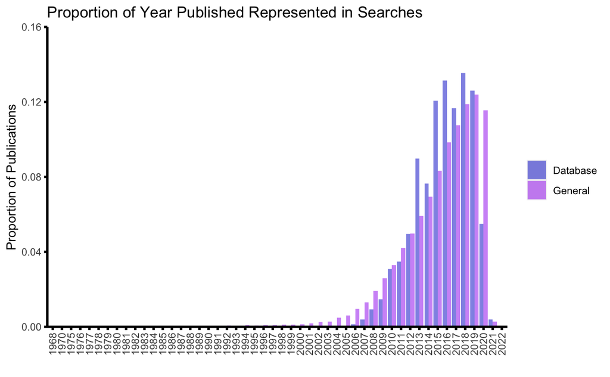

```r
ggplot(data=data_frame_new_d) +
 geom_bar(aes(x=year, y = proportion, fill=source),
          position="dodge", stat="identity", alpha=0.5) +
  scale_fill_manual(values = c("mediumblue", "purple"))+
  theme(legend.position = "right", legend.title=element_blank(), axis.text.x = element_text(angle=90, vjust=.5, hjust=1),panel.grid.major = element_blank(),
  panel.grid.minor = element_blank(),
  panel.border = element_blank(),
  panel.background = element_blank(),
  plot.background = element_blank(),
  axis.line = element_line(colour="black", size = 1),
  axis.ticks = element_line(colour="black", size = 1)) +
  ggtitle("Proportion of Year Published Represented in Searches") +
  ylab("Proportion of Publications") +
  xlab("") +
  scale_y_continuous(limits = c(0, 0.16), expand = expansion(mult = c(0, 0)))
```

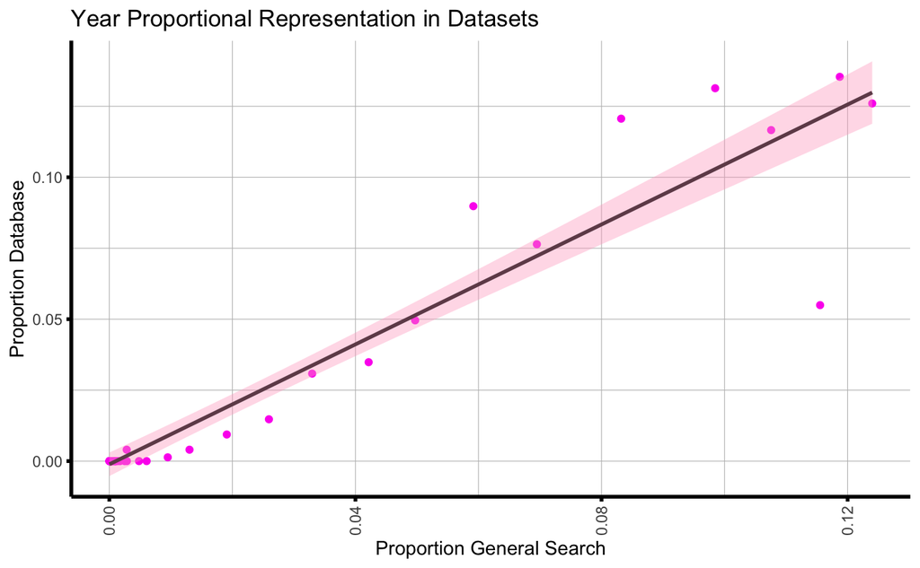

```r
plott <- ggplot(data_frame_d, aes(x=(Proportion_Gen), y=(Proportion_Database))) +
  geom_point( color="#fc2dee") +
  geom_smooth(method=lm , color="#704b58", fill="#ffabc8", se=TRUE) +
  theme(axis.text.x = element_text(angle=90, vjust=.5, hjust=1),
  panel.grid.minor = element_line(size=(0.2), colour="grey"),
  panel.grid.major = element_line(size=(0.2), colour="grey"),
  panel.background = element_blank(),
  plot.background = element_blank(),
  axis.line = element_line(colour="black", size = 1),
  axis.ticks = element_line(colour="black", size = 1)) +
  ggtitle("Year Proportional Representation in Datasets") +
  xlab("Proportion General Search")+
  ylab("Proportion Database")

plott
```

```r
equation_date <- lm(Proportion_Database ~ Proportion_Gen, data_frame_d)
r2_date = format(summary(equation_date)$r.squared, digits = 3)
```

Material Cancer Analysis We can also look at information like how material names or types of cancer could be in the abstracts. To do this follow the code below. The first part makes material names and types of cancer into a dfm to cross reference with our abstract dfm.

```r
metal_cancer<- read.csv(file = file.choose()) [ ,c('material', 'cancer')]    # Step 1 read in csv column of interest
metal<- metal_cancer$material

#Create a docs by using corpus
mymetalcorpus <- corpus(paste(metal, collapse = " "))

token_metal <-
  tokens(
    mymetalcorpus,
    remove_numbers = TRUE,
    remove_punct = TRUE,
    remove_symbols = TRUE,
    split_hyphens = TRUE,
    include_docvars = TRUE
  )


metaldfm <- dfm(token_metal,
            tolower = FALSE,
)

metaldfm <- convert(metaldfm, to = "data.frame")
```

Now we must try to only search for material in the abstracts

```r
# Load in the material information and compare with our tokens

metaldata <- metal
token2 <- tokens_select(token_Gen, pattern = metaldata, padding = FALSE)  # This will only select tokens that match with the list we added in
# Clean tokens and prepare for visualization
token2_clean <- tokens_select(
  token2,
  c("[\\d-]", "[[:punct:]]", "^.{1,2}$"),
  selection = "remove",
  valuetype = "regex",
  verbose = TRUE
)
```

```
removed 0 features
```

```r
mydfmWoS <- dfm(token2_clean,
             tolower = TRUE,             # This makes it not case sensitive
)

tstatWoS<-textstat_frequency(mydfmWoS)
# proportional data
mydfmWoS_prop <- dfm_weight(mydfmWoS, scheme = "prop")
tstatWoS_prop<-textstat_frequency(mydfmWoS_prop)

dfmWoS_dataframe <- convert(mydfmWoS, to = "data.frame")

tokenRE <- tokens_select(token_research, pattern = metaldata, padding = FALSE)  # This will only select tokens that match with the list we added in
# Clean tokens and prepare for visualization
tokenRE_clean <- tokens_select(
  tokenRE,
  c("[\\d-]", "[[:punct:]]", "^.{1,2}$"),
  selection = "remove",
  valuetype = "regex",
  verbose = TRUE
)
```

```
removed 0 features
```

```r
mydfmRE <- dfm(tokenRE_clean,
             tolower = TRUE,             # This makes it not case sensitive
)
tstatRE<-textstat_frequency(mydfmRE)
# proportional data
mydfmRE_prop <- dfm_weight(mydfmRE, scheme = "prop")
tstatRE_prop<-textstat_frequency(mydfmRE_prop)
dfmRE_dataframe <- convert(mydfmRE, to = "data.frame")
```

We can visualize the material names used in the abstracts now by plotting them using the package ggplot2

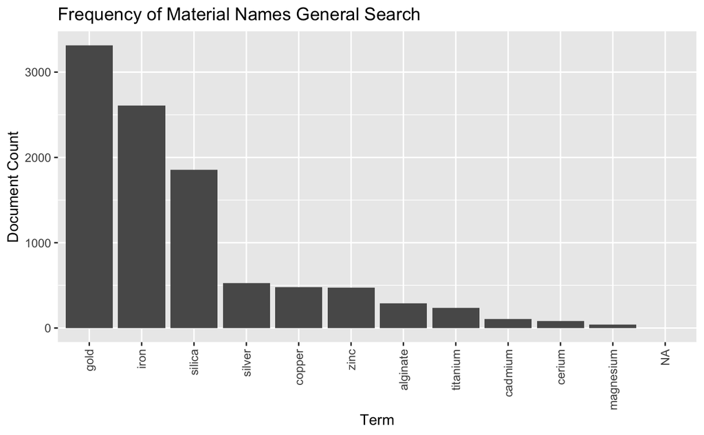

```r
# Plot WoS
ggplot(tstatWoS[1:14, ], aes(x = reorder(feature, -docfreq), y = docfreq))+
  geom_bar(stat="identity")+
  theme(axis.text.x=element_text(angle=90,hjust=1,vjust=0.5))+
  labs(x = "Term", y = "Document Count", title = "Frequency of Material Names General Search")
```

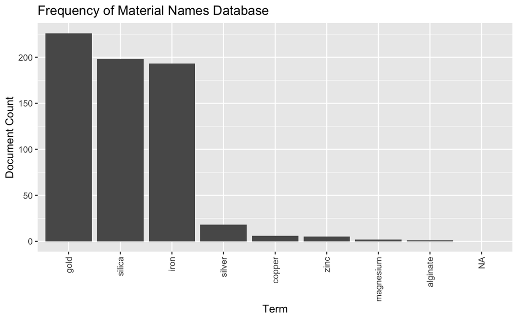

```r
# Plot research
ggplot(tstatRE[1:10, ], aes(x = reorder(feature, -docfreq), y = docfreq))+
  geom_bar(stat="identity")+
  theme(axis.text.x=element_text(angle=90,hjust=1,vjust=0.5))+
  labs(x = "Term", y = "Document Count", title = "Frequency of Material Names Database")
```

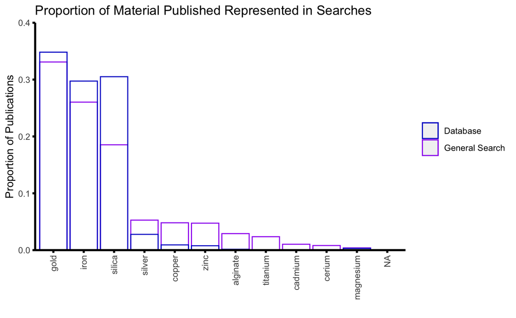

```r
legend_colors <- c("General Search"="purple", "Database"="mediumblue")
tstatWoS$proportional_docfreq <- tstatWoS$docfreq/sum(tstatWoS$docfreq)  # prop of x material over total materials
tstatRE$proportional_docfreq <- tstatRE$docfreq/sum(tstatRE$docfreq) # prop of x material over total materials
ggplot(NULL, aes(x = reorder(feature, -proportional_docfreq), y = proportional_docfreq)) +
  geom_bar(data = tstatWoS[1:14, ], aes(color="General Search"), fill = NA, stat="identity") +  # general
  geom_bar(data=tstatRE[1:10, ], aes(color="Database"), fill = NA, stat="identity") +  # research
  scale_y_continuous()+
 theme(legend.position = "right", legend.title=element_blank(), axis.text.x = element_text(angle=90, vjust=.5, hjust=1),panel.grid.major = element_blank(),
  panel.grid.minor = element_blank(),
  panel.border = element_blank(),
  panel.background = element_blank(),
  plot.background = element_blank(),
  axis.line = element_line(colour="black", size = 1),
  axis.ticks = element_line(colour="black", size = 1)) +
  ggtitle("Proportion of Material Published Represented in Searches") +
  ylab("Proportion of Publications") +
  xlab("") +
  scale_color_manual(values = legend_colors)+
  scale_y_continuous(limits = c(0, 0.4), expand = expansion(mult = c(0, 0)))
```

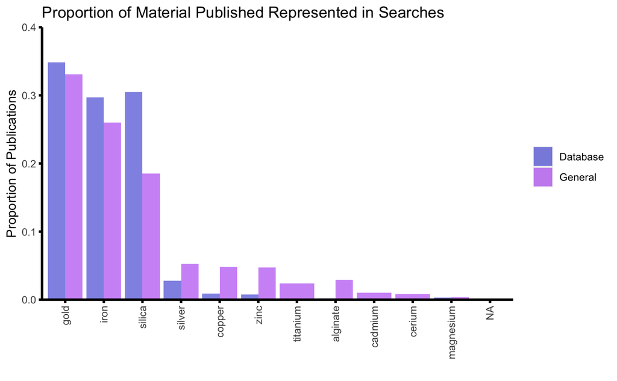

```r
data_frame_new = data.frame(source= c("General", "General", "General", "General", "General", "General", "General", "General", "General", "General", "General", "General", "General", "General", "Database", "Database", "Database", "Database", "Database", "Database", "Database", "Database", "Database", "Database"),
                  frequency = c(tstatWoS[1:14, ]$proportional_docfreq,tstatRE[1:10, ]$proportional_docfreq),
                  feature= c(tstatWoS[1:14, ]$feature, tstatRE[1:10, ]$feature) )

ggplot(data=data_frame_new) +
 geom_bar(aes(x=reorder(feature, -frequency), y=frequency, fill=source),
          position="dodge", stat="identity", alpha=0.5) +
  scale_fill_manual(values = c("mediumblue", "purple"))+
  theme(legend.position = "right", legend.title=element_blank(), axis.text.x = element_text(angle=90, vjust=.5, hjust=1),panel.grid.major = element_blank(),
  panel.grid.minor = element_blank(),
  panel.border = element_blank(),
  panel.background = element_blank(),
  plot.background = element_blank(),
  axis.line = element_line(colour="black", size = 1),
  axis.ticks = element_line(colour="black", size = 1)) +
  ggtitle("Proportion of Material Published Represented in Searches") +
  ylab("Proportion of Publications") +
  xlab("") +
  scale_y_continuous(limits = c(0, 0.4), expand = expansion(mult = c(0, 0)))
```

```r
#Create a docs by using corpus
metal_cancer_corpus <- corpus(paste(metal_cancer, collapse = " "))
token_metal_cancer <-
  tokens(
    metal_cancer_corpus,
    remove_numbers = TRUE,
    remove_punct = TRUE,
    remove_symbols = TRUE,
    split_hyphens = TRUE,
    include_docvars = TRUE
  )
metal_cancer_dfm <- dfm(token_metal_cancer,
            tolower = FALSE,
)

metal_cancer_df <- convert(metal_cancer_dfm, to = "data.frame")
write.table(metal_cancer_df, file = "~/Desktop/Material_Cancer_List.txt", sep = ",", quote=FALSE) # Write to file
# Load in the file with gene list and compare with our tokens
metal_cancer_data <- scan("~/Desktop/Material_Cancer_List.txt",  character(), sep=",")
```

```
Read 57 items
```

```r
tokenWoS2 <- tokens_select(token_Gen, pattern = metal_cancer_data, padding = FALSE)  # This will only select tokens that match with the list we added in
# Clean tokens and prepare for visualization
tokenWoS2_clean <- tokens_select(
  tokenWoS2,
  c("[\\d-]", "[[:punct:]]", "^.{1,2}$"),
  selection = "remove",
  valuetype = "regex",
  verbose = TRUE
)
```

```
removed 2 features
```

```r
mydfmWoS2 <- dfm(tokenWoS2_clean,
             tolower = TRUE,             # This makes it not case sensitive
)



tstatWoS2<-textstat_frequency(mydfmWoS2)
# proportional data
mydfmWoS2_prop <- dfm_weight(mydfmWoS2, scheme = "prop")
tstatWoS2_prop<-textstat_frequency(mydfmWoS2_prop)
dfmWoS2_dataframe <- convert(mydfmWoS2, to = "data.frame")
tokenRE2 <- tokens_select(token_research, pattern = metal_cancer_data, padding = FALSE)  # This will only select tokens that match with the list we added in
# Clean tokens and prepare for visualization
tokenRE2_clean <- tokens_select(
  tokenRE2,
  c("[\\d-]", "[[:punct:]]", "^.{1,2}$"),
  selection = "remove",
  valuetype = "regex",
  verbose = TRUE
)
```

```
removed 2 features
```

```r
mydfmRE2 <- dfm(tokenRE2_clean,
             tolower = TRUE,             # This makes it not case sensitive
)
tstatRE2<-textstat_frequency(mydfmRE2)
# proportional data
mydfmRE2_prop <- dfm_weight(mydfmRE2, scheme = "prop")
tstatRE2_prop<-textstat_frequency(mydfmRE2_prop)
dfmRE2_dataframe <- convert(mydfmRE2, to = "data.frame")
```

So now we can get combination of any cancer and any material 17 material and 12 cancer

```r
library("stringr")
material_list <- metal_cancer$material
cancer_list <- (metal_cancer$cancer[1:12]) #only 12 cancer types
all_combo <- expand.grid(material=material_list, cancer=cancer_list)
all_combo$mat <- str_trim(all_combo$material)  # some material have a space so we need to remove any of these
```

Now we can use these combinations and count how many papers use the combination of cancer and material

```r
dfmWoS2_dataframe[dfmWoS2_dataframe != 0] <- 1
dfmWoS2_dataframe[2:length(dfmWoS2_dataframe)][dfmWoS2_dataframe[2:length(dfmWoS2_dataframe)] != 0]<- 1 # replace any big number with only 1

dfmRE2_dataframe[dfmRE2_dataframe != 0] <- 1
dfmRE2_dataframe[2:length(dfmRE2_dataframe)][dfmRE2_dataframe[2:length(dfmRE2_dataframe)] != 0]<- 1 # replace any big number with only 1

# now we can loop through the all_combo dataframe to collect value of the combinations

all_combo$sumWoS=0
all_combo$sumRE=0
for (i in 1:204) {
  MATERIAL <- as.vector(all_combo$mat[i])
  CANCER <- as.vector(all_combo$cancer[i])
  all_combo$sumWoS[i] <- sum(dfmWoS2_dataframe[MATERIAL]== 1 & dfmWoS2_dataframe[CANCER] == 1)
  all_combo$sumRE[i] <- tryCatch (sum(dfmRE2_dataframe[MATERIAL]== 1 & dfmRE2_dataframe[CANCER] == 1),
           error = function(e){"0"
         })
}
all_combo$sumRE <- as.numeric(all_combo$sumRE)
```

Now we can plot mat v cancer

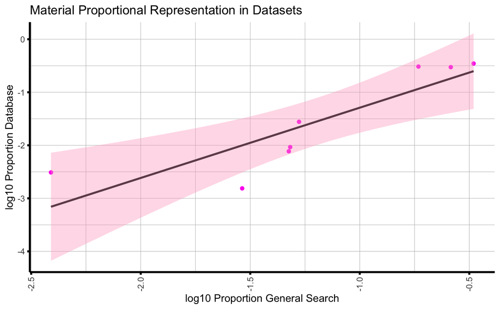

```r
tstatWoS$proportional_docfreq <- tstatWoS$docfreq/sum(tstatWoS$docfreq)  # prop of x material over total materials

tstatRE$proportional_docfreq <- tstatRE$docfreq/sum(tstatRE$docfreq) # prop of x material over total materials


# make merged df with general and research do prop metals and have research v general search
metal_DF_WoS2 <- tstatWoS[,c('feature','proportional_docfreq')]
metal_DF_RE2 <- tstatRE[,c('feature','proportional_docfreq')]

metal_merge <- inner_join(metal_DF_WoS2, metal_DF_RE2, by=c('feature'='feature'))

plot <- ggplot(metal_merge, aes(x=log10(proportional_docfreq.x), y=log10(proportional_docfreq.y))) +
  geom_point( color="#fc2dee") +
  geom_smooth(method=lm , color="#704b58", fill="#ffabc8", se=TRUE) +
  theme(axis.text.x = element_text(angle=90, vjust=.5, hjust=1),
  panel.grid.minor = element_line(size=(0.2), colour="grey"),
  panel.grid.major = element_line(size=(0.2), colour="grey"),
  panel.background = element_blank(),
  plot.background = element_blank(),
  axis.line = element_line(colour="black", size = 1),
  axis.ticks = element_line(colour="black", size = 1)) +
  ggtitle("Material Proportional Representation in Datasets") +
  xlab("log10 Proportion General Search")+
  ylab("log10 Proportion Database")

plot
```

```r
equation_metal <- lm(log10(proportional_docfreq.y) ~ log10(proportional_docfreq.x), metal_merge)
r2_metal = format(summary(equation_metal)$r.squared, digits = 3)

#note: log10 proportion is log10 transformed (count of material) / (count of all materials)
```

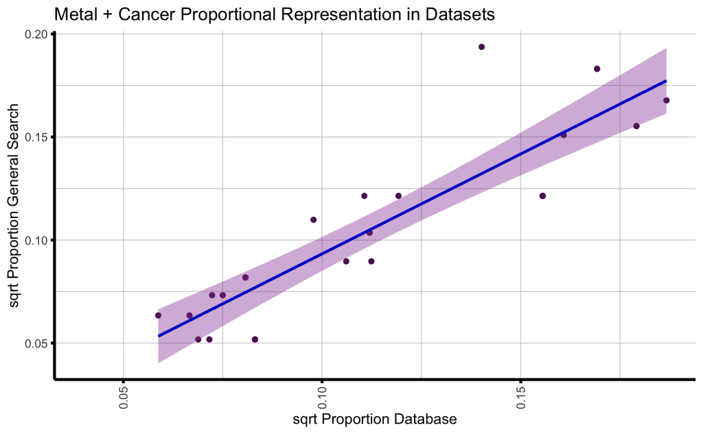

```r
all_combo$Normalized_Freq_WoS <- all_combo$sumWoS/nrow(dfmWoS_dataframe)*(10/2)
all_combo$Normalized_Freq_RE <- all_combo$sumRE/nrow(dfmRE_dataframe)

plot2 <- ggplot(all_combo, aes(x=sqrt(Normalized_Freq_WoS), y=sqrt(Normalized_Freq_RE))) +
  geom_point( color="#5B1B61") +
  geom_smooth(method=lm , color="mediumblue", fill="#9543A3", se=TRUE) +
  theme(axis.text.x = element_text(angle=90, vjust=.5, hjust=1),
  panel.grid.minor = element_line(size=(0.2), colour="grey"),
  panel.grid.major = element_line(size=(0.2), colour="grey"),
  panel.background = element_blank(),
  plot.background = element_blank(),
  axis.line = element_line(colour="black", size = 1),
  axis.ticks = element_line(colour="black", size = 1)) +
  ggtitle("Metal + Cancer Proportional Representation in Datasets") +
  ylab("sqrt Proportion General Search")+
  xlab("sqrt Proportion Database") +
  xlim(0.04, NA)+
  ylim(0.04, NA)
plot2
```

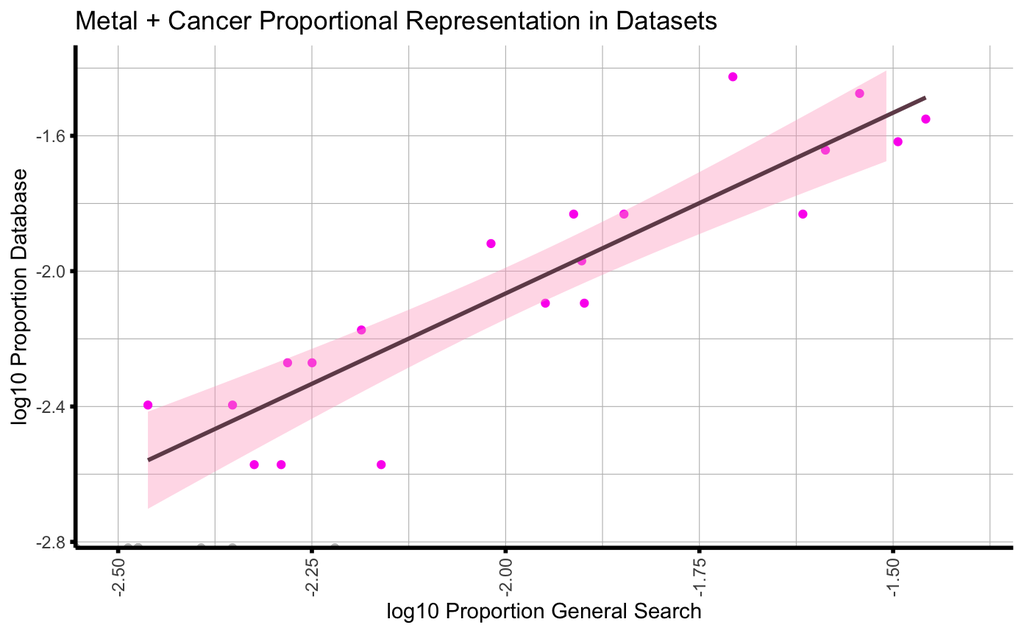

```r
sorted_all_combo1 <- all_combo[order(all_combo$sumRE),]
sorted_all_combo <-  subset(sorted_all_combo1, select = -material)

zero_RE_df <- sorted_all_combo[sorted_all_combo$sumRE <= 1,]
non_zero_RE_df <- unique(sorted_all_combo[sorted_all_combo$sumRE > 1,])
plot3 <- ggplot() +
  geom_point(data=non_zero_RE_df, aes(x = log10(Normalized_Freq_WoS), y = log10(Normalized_Freq_RE)),  color="#fc2dee") +
  geom_smooth(data=non_zero_RE_df, aes(x = log10(Normalized_Freq_WoS), y = log10(Normalized_Freq_RE)), method=lm , color="#704b58", fill="#ffabc8", se=TRUE)+
  geom_point(data=zero_RE_df, aes(x = log10(Normalized_Freq_WoS), y = log10(Normalized_Freq_RE)), color="grey") +
  theme(axis.text.x = element_text(angle=90, vjust=.5, hjust=1),
  panel.grid.minor = element_line(size=(0.2), colour="grey"),
  panel.grid.major = element_line(size=(0.2), colour="grey"),
  panel.background = element_blank(),
  plot.background = element_blank(),
  axis.line = element_line(colour="black", size = 1),
  axis.ticks = element_line(colour="black", size = 1)) +
  ggtitle("Metal + Cancer Proportional Representation in Datasets") +
  xlab("log10 Proportion General Search")+
  ylab("log10 Proportion Database") +
  xlim(-2.5, -1.4)+
  ylim(-2.75, -1.4)
plot3
```

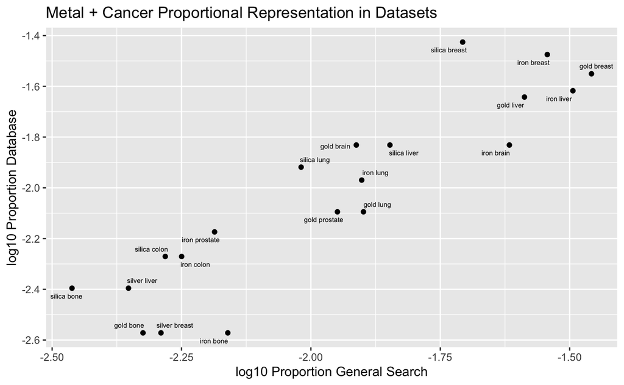

```r
log_trans<-data.frame(matrix(nrow = 20, ncol = 0))
log_trans$Name <-paste( non_zero_RE_df$mat, non_zero_RE_df$cancer, sep = ' ')
log_trans$WoS <- log10(non_zero_RE_df$Normalized_Freq_WoS)
log_trans$RE <- log10(non_zero_RE_df$Normalized_Freq_RE)

plot4 <- ggplot(log_trans, aes(WoS,RE)) +
  geom_point() +
  geom_text_repel(aes(label = Name), size = 2) +
  ggtitle("Metal + Cancer Proportional Representation in Datasets") +
  xlab("log10 Proportion General Search")+
  ylab("log10 Proportion Database")
plot4
```

```r
equation_mat_metal <- lm(log10(Normalized_Freq_RE) ~ log10(Normalized_Freq_WoS), non_zero_RE_df)
r2_mat_metal = format(summary(equation_mat_metal)$r.squared, digits = 3)
eq_mat_metal = (equation_mat_metal)$coefficients
```

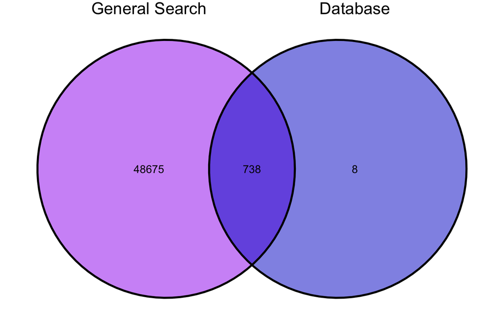

```r
general <- Combo_NP_CSV$DOI
research <- research_NP_CSV$DOI
library(ggvenn)

xx = list('General Search'=(general), 'Database'=(research))
ggvenn(xx, show_percentage=FALSE,  fill_color = c("purple", "mediumblue"))
```